# eqvis Vignette

Kim Aquilino

2017-07-19

The `eqvis` package provides functions for cleaning and plotting the NOAA significant earthquake dataset using either a timeline or map. A sample of the NOAA data `sample_eq` is provided.

## Clean Data

The earthquake data must be cleaned to utilize the timeline and map functions by using the `eq_clean_data` function. With this function, the country and colon are removed from the `LOCATION_NAME` and it is converted to title case. This provides for a better label. A `DATE` column is created from the date parts (`YEAR`, `MONTH`, `DAY`). The `LATITUDE` and `LONGITUDE` columns are converted to numerics.

This example demonstrates the use of `eq_clean_data` showing the before and after values. Notice the difference in values for the location name and the added `DATE`.

```r
library(eqvis)
sample3 <- head(sample_eq[,c("YEAR","MONTH","DAY","LOCATION_NAME","LATITUDE","LONGITUDE")],3)
print.data.frame(sample3,row.names=FALSE)
```

```
##  YEAR MONTH DAY                         LOCATION_NAME LATITUDE LONGITUDE
##  2000     9   3                     CALIFORNIA:  NAPA   38.379  -122.413
##  2001     2  28 WASHINGTON:  OLYMPIA, SEATTLE, TACOMA   47.149  -122.727
##  2001     9   9              CALIFORNIA:  LOS ANGELES   34.059  -118.387
```

```r
print.data.frame(eq_clean_data(sample3),row.names=FALSE)
```

```
##  YEAR MONTH DAY            LOCATION_NAME LATITUDE LONGITUDE       DATE
##  2000     9   3                     Napa   38.379  -122.413 2000-09-03
##  2001     2  28 Olympia, Seattle, Tacoma   47.149  -122.727 2001-02-28
##  2001     9   9              Los Angeles   34.059  -118.387 2001-09-09
```

## Timeline Info

A timeline can be produced using `ggplot2` with the `geom_timeline`/`stat_timeline` functions. It will plot a timeline with points for each earthquake and can optionally include a size and color/fill aesthectics. If `xmin` and `xmax` aesthetics are provided, `stat_timeline` will subset the data. The `geom_timeline_label` function can be used to add a label geom. It wil print the label aesthetic for the top `n_max` earthquakes in terms of magnitude.

This example demonstrates the use of `eq_clean_data`, `geom_timeline`, and `geom_timeline_label`.

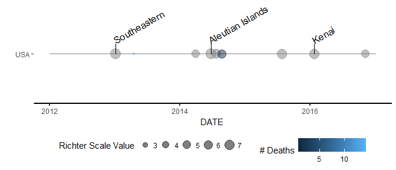

```r
library(ggplot2)
library(scales)
library(eqvis)

ggplot(data=subset(eq_clean_data(sample_eq), !is.na(EQ_PRIMARY) & COUNTRY %in% c("USA")),
       aes(x = DATE,
           y = COUNTRY,
           size = EQ_PRIMARY,
           xmin = as.Date('2012-01-01',"%Y-%m-%d"),
           xmax = as.Date('2016-12-31',"%Y-%m-%d"),
           color = DEATHS,
           fill = DEATHS,
           label = LOCATION_NAME)) +
    geom_timeline(alpha = .5) +
    scale_size_continuous(name = "Richter Scale Value") +
    scale_color_continuous(name = "# Deaths") +
    scale_fill_continuous(guide=FALSE) +
    labs(x = "DATE", y = "") +
    geom_timeline_label(aes(n_max = 3)) +
    theme(legend.position = "bottom",
          legend.key = element_blank(),
          legend.box = "horizontal",
          panel.background = element_blank(),
          axis.line.x = element_line(size = 1, color = "black"),
          axis.ticks.x = element_line(size = 1))
```

## Map Info

A map can be produced using eq_map(). It will display circle markers at the lat/lon locations with a radius based on the magnitude of the earthquake and popup text reflecting the annotation column provided. An optional eq_create_label function is provided that will generate label text `popup_text` using the location name, magnitude and deaths for the earthquake.

This example demonstrates the use of `eq_clean_data`, `eq_create_label`, and `eq_map`.

```r
library(eqvis)
library(leaflet)
library(magrittr)
library(dplyr)
library(lubridate)

sample_eq %>%
eq_clean_data() %>%
dplyr::filter(COUNTRY == "MEXICO" & lubridate::year(DATE) >= 2000) %>%
dplyr::mutate(popup_text = eq_create_label(.)) %>%
eq_map(annot_col = "popup_text")
```

[interactive chart not shown]

## Data

A `sample_eq` dataset is provided. It is a subset of the complete NOAA dataset, filtered for `COUNTRY` values `USA` and `MEXICO` and `YEAR` 2000-2017. It has the following structure:

```
## 'data.frame':    63 obs. of  9 variables:
##  $ YEAR         : int  2000 2001 2001 2002 2002 2002 2002 2002 2002 2003 ...
##  $ MONTH        : int  9 2 9 1 2 4 9 10 11 1 ...
##  $ DAY          : int  3 28 9 30 22 20 25 23 3 22 ...
##  $ LOCATION_NAME: Factor w/ 3745 levels "","AFGHANISTAN",..: 373 3729 368 2535 2476 2629 2432 55 71 2537 ...
##  $ COUNTRY      : Factor w/ 153 levels "AFGHANISTAN",..: 145 145 145 86 86 145 86 145 145 86 ...
##  $ LATITUDE     : num  38.4 47.1 34.1 18.2 32.3 ...
##  $ LONGITUDE    : num  -122.4 -122.7 -118.4 -95.9 -115.3 ...
##  $ DEATHS       : int  NA 1 NA NA NA NA NA NA NA 29 ...
##  $ EQ_PRIMARY   : num  5 6.8 4.2 5.9 5.5 5.2 5.3 6.7 7.9 7.5 ...
```

The complete NOAA earthquake dataset can be accessed from: https://www.ngdc.noaa.gov/nndc/struts/results?type_0=Exact&query_0=$ID&t=101650&s=13&d=189&dfn=signif.txt. It contains information about 5,933 earthquakes around the world over an approximately 4,000 year time span.

Note: This package was developed to work with positive years (A.D.) only.